# Causal Inference - Estimation

Michael Knaus

SoSe 25

These are the goals of today:

- Generate a confounded data generating process
- Implement different estimators

```
if (!require("tidyverse")) install.packages("tidyverse", dependencies = TRUE); library(tidyverse)
if (!require("patchwork")) install.packages("patchwork", dependencies = TRUE); library(patchwork)
if (!require("np")) install.packages("np", dependencies = TRUE); library(np)
if (!require("reshape2")) install.packages("reshape2", dependencies = TRUE); library(reshape2)
if (!require("foreach")) install.packages("foreach", dependencies = TRUE); library(foreach)
if (!require("doParallel")) install.packages("doParallel", dependencies = TRUE); library(doParallel)
```

# Simulate a data generating process

Define and program a data generating process with

- One continuous confounding variable $X$
- A binary treatment $W$
- A continuous outcome $Y$

## Define data generating process

Define a toy parametric model:

- $X := f_X(U_X) = uniform(-1,1)$
- $W := f_W(X,U_W) = 1[\alpha_0 + \alpha_1 X + U_W > 0]$ with $U_W \sim logistic(0,1)$
- $Y := f_Y(W,X,U_Y) = \beta_0 + \beta_1 X + \beta_2 W + \beta_3 W X + U_Y$ with $U_Y \sim \mathcal{N}(0,1)$

and recall the essential causal implications

1. $\gamma_0(X) := E[Y(0)|X] = E[\beta_0 + \beta_1 X + U_Y|X] = \beta_0 + \beta_1 X + \underbrace{E[U_Y|X]}_{=0} = \beta_0 + \beta_1 X$
2. $\gamma_1(X) := E[Y(1)|X] = \beta_0 + \beta_1 X + \beta_2 + \beta_3 X$
3. CATE $\tau(X) := E[Y(1) - Y(0)|X] = \beta_2 + \beta_3 X$
4. ATE $E[Y(1) - Y(0)] = \beta_2 + \beta_3 \underbrace{E[X]}_{=0} = \beta_2$
5. The treatment probability $e(X) := P(W = 1 | X) = \frac{e^{\alpha_0 + \alpha_1 X}}{1 + e^{\alpha_0 + \alpha_1 X}}$

Let’s plot the DGP for

$$\alpha_0 = \beta_0 = \beta_1 = \beta_2 =
0$$

and
$$\alpha_1 = \beta_3 = 1$$

```
set.seed(1234)

alpha0 = 0
alpha1 = 1
beta0 = 0
beta1 = 0
beta2 = 0
beta3 = 1
e = function(x){exp(alpha0 + alpha1 * x) / (1 + exp(alpha0 + alpha1 * x))}
m0 = function(x){beta0 + beta1 * x}
m1 = function(x){beta0 + beta1 * x + beta2 + beta3 * x}
tau = function(x){m1(x) - m0(x)}

g1 = data.frame(x = c(-1, 1)) %>% ggplot(aes(x)) + stat_function(fun=e,linewidth=1) + ylab("e(x)") + xlab("X1")
g2 = data.frame(x = c(-1, 1)) %>% ggplot(aes(x)) + stat_function(fun=m1,linewidth=1,aes(colour="gamma1")) +
  stat_function(fun=m0,linewidth=1,aes(colour="gamma0")) + ylab("gamma(x)") + xlab("X1")
g3 = data.frame(x = c(-1, 1)) %>% ggplot(aes(x)) + stat_function(fun=tau,linewidth=1) + ylab(expression(tau(x))) + xlab("X1")
g1 / g2 / g3
```

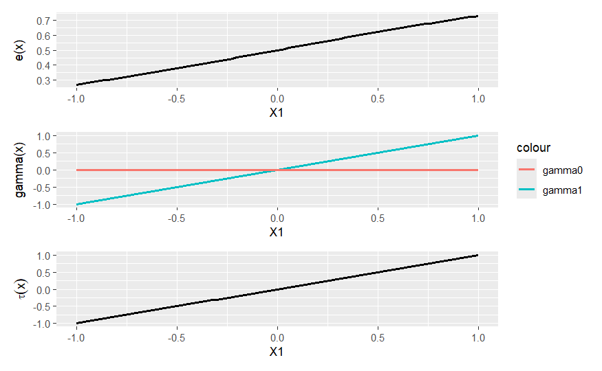

What kind of world does this create?

- has heterogeneous treatment effects
- no RCT a.k.a. observational study a.k.a. confounding

# Draw sample

Finally simulate a dataset with $n=4000$ from this data generating process:

```
n = 4000
```

- Draw $X$:

```
X = runif(n,-1,1)
hist(X)
```

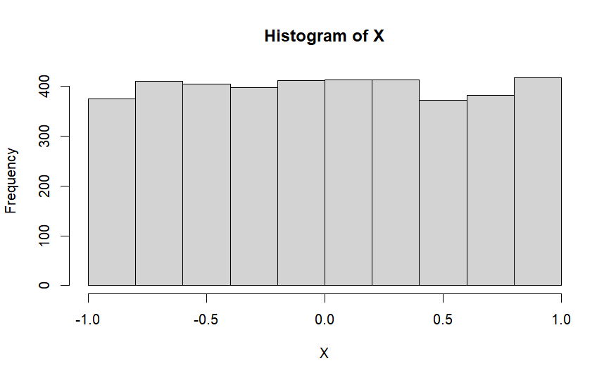

- Generate $W$:

```
UW = rlogis(n)
# hist(UW)
W = (alpha0 + alpha1 * X + UW > 0) * 1
table(W)
```

```
W
   0    1
1988 2012
```

- Compare the distributions of confounders between treated and controls

using histograms

```
# Combine X and W into a data frame
data <- data.frame(X = X, W = as.factor(W))

# Create overlapping histograms
ggplot(data, aes(x = X, fill = W)) +
  geom_histogram(position = "identity", alpha = 0.5, bins = 30) +
  scale_fill_manual(values = c("blue", "red"), labels = c("W = 0", "W = 1")) +
  theme_minimal() +
  labs(title = "Overlapping Histograms of X by W",
       x = "X",
       y = "Count",
       fill = "Group")
```

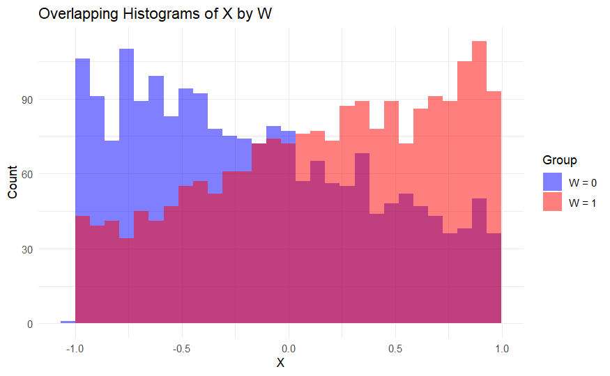

using boxplots

```
# Create boxplots
ggplot(data, aes(x = W, y = X, fill = W)) +
  geom_boxplot(alpha = 0.7) +
  scale_fill_manual(values = c("blue", "red"), labels = c("W = 0", "W = 1")) +
  theme_minimal() +
  labs(title = "Boxplots of X by W",
       x = "Group",
       y = "X",
       fill = "Group") +
  theme(legend.position = "none")  # Remove legend if not needed
```

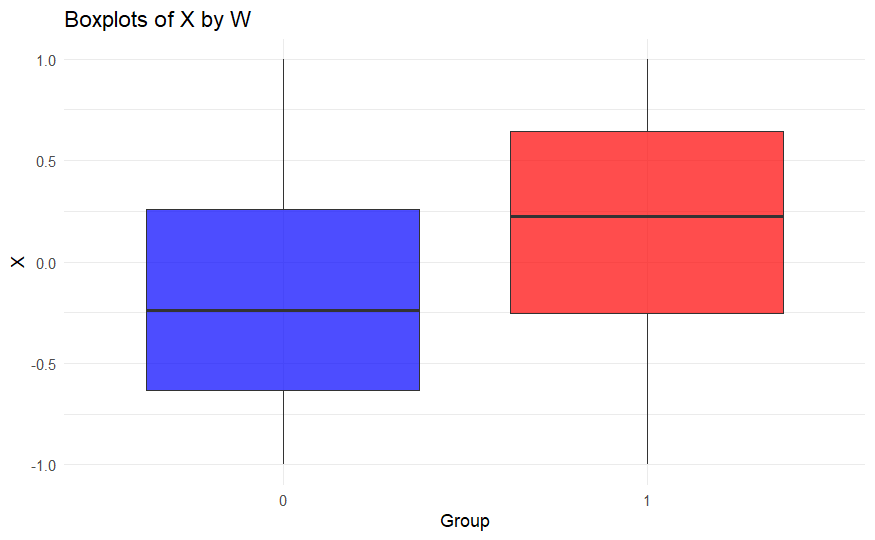

What do you observe?

Unbalanced confounder distributions.

- Generate $Y$:

```
UY = rnorm(n)
Y = beta0 + beta1 * X + beta2 * W + beta3 * X * W + UY
```

Explicitly calculate and plot the two potential outcomes:

```
Y0 = beta0 + beta1 * X + UY
Y1 = beta0 + beta1 * X + beta2  + beta3 * X + UY

# Combine the data into a data frame for ggplot
data = data.frame(
  value = c(Y0, Y1),
  group = factor(rep(c("Y0", "Y1"), each = length(Y0)))
)

# Create the overlapping histograms
ggplot(data, aes(x = value, fill = group)) +
  geom_histogram(alpha = 0.5, position = "identity", bins = 30) +
  labs(title = "Overlapping Histograms of Y0 and Y1",
       x = "Value",
       y = "Count") +
  theme_minimal() +
  scale_fill_manual(values = c("blue", "red"))
```

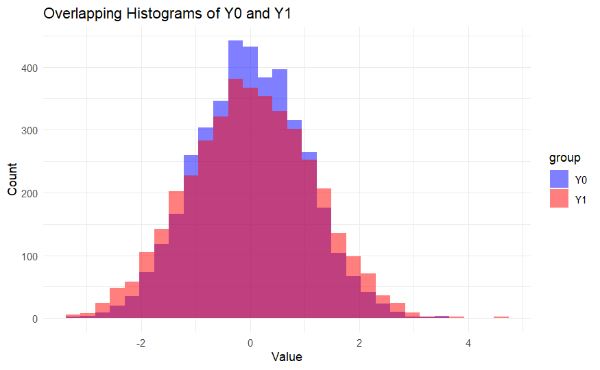

## Estimation

### Naive mean comparison

As benchmark, estimate the ATE using a mean comparison:

```
ate_mc = mean(Y[W==1]) - mean(Y[W==0])
ate_mc
```

```
[1] 0.1430097
```

Would you trust this number?

### Nonparametric regression adjustment

Recall that the estimator takes the following form
$$\begin{align}
\hat{\tau}^{RA} = \frac{1}{N}\sum_{i = 1}^N (\hat{E}[Y_i \mid X_i,
W_i = 1] - \hat{E}[Y_i \mid X_i, W_i = 0])
\end{align}$$

This means we need nonparametric estimates of

- $\hat{E}[Y \mid X, W = 0]$ for each unit
- $\hat{E}[Y \mid X, W = 1]$ for each unit

There are plenty of options to implement this. We opt for a simple one:

- The conditioning on $W=0$ and $W=1$ is implemented by separating treated and controls to learn separate models

```
# Split the data into treated and control groups
data_treated = data.frame(X = X[W == 1], Y = Y[W == 1])
data_control = data.frame(X = X[W == 0], Y = Y[W == 0])
```

Now we apply standard kernel regression to estimate an outcome model

for the treated,

```
model_treated = npreg(Y ~ X, data = data_treated)
```

```
Multistart 1 of 1 |
Multistart 1 of 1 |
Multistart 1 of 1 |
Multistart 1 of 1 /
Multistart 1 of 1 |
Multistart 1 of 1 |
```

```
plot(model_treated)
```

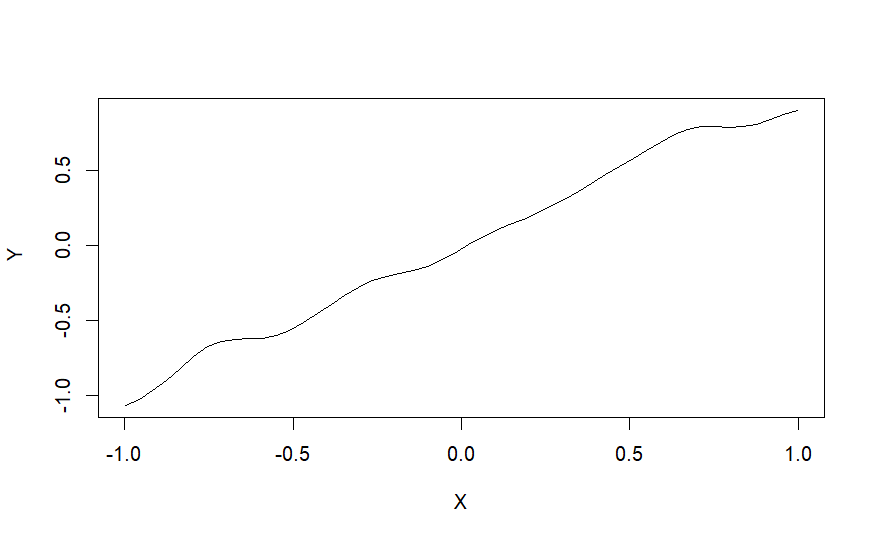

the control group

```
model_control = npreg(Y ~ X, data = data_control)
```

```
Multistart 1 of 1 |
Multistart 1 of 1 |
Multistart 1 of 1 |
Multistart 1 of 1 /
Multistart 1 of 1 |
Multistart 1 of 1 |
```

```
plot(model_control)
```

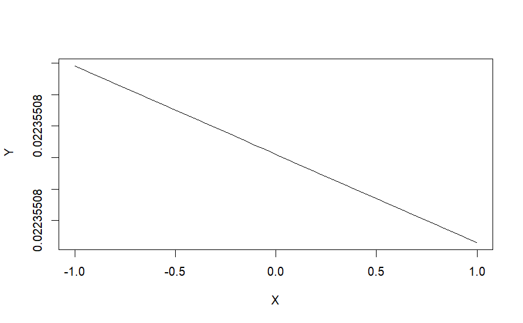

Now we use the estimated models to estimate

- $\hat{E}[Y \mid X, W = 0]$ for each unit

```
Y0hat_ra = predict(model_control, newdata = data.frame(X = X))
```

- $\hat{E}[Y \mid X, W = 1]$ for each unit

```
Y1hat_ra = predict(model_treated, newdata = data.frame(X = X))
```

and plot the fitted lines jointly and with the true functions as dashed lines:

```
# Dummy data with two identical points
legend_data <- data.frame(x = c(1, 1), y = c(1, 1))

ggplot(data = data.frame(X = X, Y = Y, W = as.factor(W))) +
  geom_line(aes(x = X, y = Y1hat_ra), color = 'red', size = 1) +
  geom_line(aes(x = X, y = Y0hat_ra), color = 'blue', size = 1) +
  stat_function(fun = m1, color = "red", linetype = "dashed", size = 1) +
  stat_function(fun = m0, color = "blue", linetype = "dashed", size = 1) +

  # Two-point dummy lines for clean legend
  geom_line(data = legend_data, aes(x = x, y = y, color = "Treated"), size = 1, inherit.aes = FALSE) +
  geom_line(data = legend_data, aes(x = x, y = y, color = "Control"), size = 1, inherit.aes = FALSE) +

  labs(title = 'Nonparametric Regression Fit', x = 'X', y = 'Y') +
  scale_color_manual(values = c("Treated" = "red", "Control" = "blue"), name = "Group") +
  theme_minimal()
```

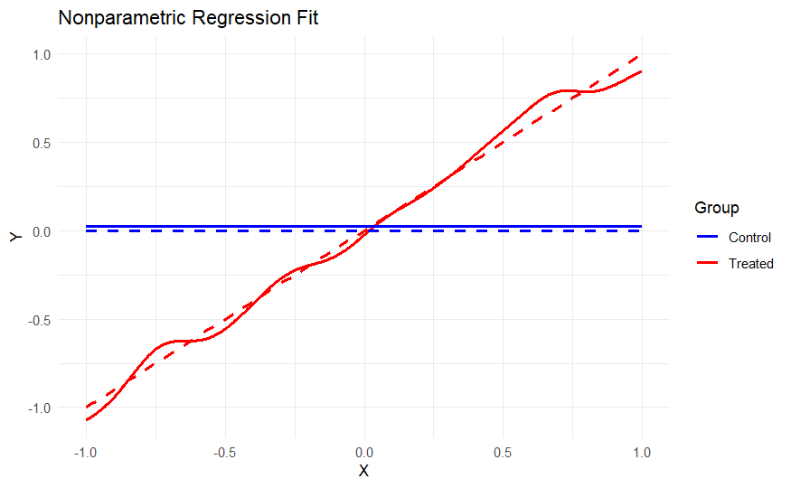

and calculate $\hat{\tau}^{RA} = \frac{1}{N}\sum_{i = 1}^N (\hat{E}[Y_i \mid X_i, W_i = 1] - \hat{E}[Y_i \mid X_i, W_i = 0])$:

```
mean(Y1hat_ra - Y0hat_ra)
```

```
[1] -0.02146345
```

### Matching

Initialize two empty vectors

```
Y0M = Y1M = rep(NA,length(Y))
```

and the group specific covariate and outcome vectors:

```
X0 = X[W==0]
Y0 = Y[W==0]
X1 = X[W==1]
Y1 = Y[W==1]
```

Now we fill the two empty vectors with

- the raw factual outcome
- and imputing the counterfactual outcome by the closest match

```
for (i in 1:length(Y)) {
  if (W[i] == 0) {
    Y0M[i] = Y[i]
    Xdist = abs(X1 - X[i])
    min_index = which.min(Xdist)
    Y1M[i] = Y1[min_index]
  }
  if (W[i] == 1) {
    Y1M[i] = Y[i]
    Xdist = abs(X0 - X[i])
    min_index = which.min(Xdist)
    Y0M[i] = Y0[min_index]
  }
}
```

Finally, we take the mean of the difference between the “completed” POs under treatment and control:

```
mean(Y1M - Y0M)
```

```
[1] 0.0005168576
```

### (optional self-study) Propensity score matching

In our simple scenario with only one covariate, propensity score matching is not required.

However, it would follow the same matching protocol as above but using the propensity score instead of the raw X.

For the sake of the argument, you can implement it here using nonparametric and/or logistic regression to estimate the p-score.

### Inverse probability weighting

To implement inverse probability weighting (IPW), we need to estimate the treatment probability $e(X) = P(W=1|X)$ for each unit. Let’s do this again running a nonparametric regression:

```
model_ex_np = npreg(W ~ X)
```

```
Multistart 1 of 1 |
Multistart 1 of 1 |
Multistart 1 of 1 |
Multistart 1 of 1 /
Multistart 1 of 1 |
Multistart 1 of 1 |
```

```
plot(model_ex_np)
```

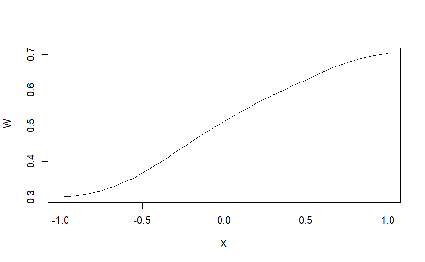

get the predictions and plot the propensity score distribution:

```
ex_np = predict(model_ex_np, newdata = data.frame(X = X))
hist(ex_np)
```

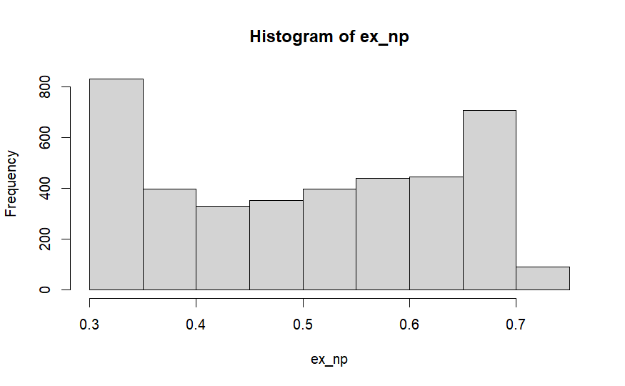

Are we concerned about common support in this setting?

Finally, we estimate ATE as
$$\hat{\tau}^{IPW} = \frac{1}{N}\sum_{i = 1}^N
\frac{W_i Y_i}{\hat{e}(X_i)} - \frac{1}{N}\sum_{i = 1}^N \frac{(1-W_i)
Y_i}{1-\hat{e}(X_i)}$$

```
mean(W * Y / ex_np) - mean((1-W) * Y / (1-ex_np))
```

```
[1] -0.008500734
```

### OLS

To conclude, we estimate the causal effect using a standard OLS specification:

```
ols = lm(Y ~ W + X)
summary(ols)
```

```
Call:
lm(formula = Y ~ W + X)

Residuals:
    Min      1Q  Median      3Q     Max
-3.3046 -0.7022 -0.0012  0.7200  3.7557

Coefficients:
            Estimate Std. Error t value Pr(>|t|)
(Intercept)  0.10528    0.02357   4.466  8.2e-06 ***
W           -0.02250    0.03395  -0.663    0.508
X            0.50236    0.02954  17.006  < 2e-16 ***
---
Signif. codes:  0 ‘***’ 0.001 ‘**’ 0.01 ‘*’ 0.05 ‘.’ 0.1 ‘ ’ 1

Residual standard error: 1.028 on 3997 degrees of freedom
Multiple R-squared:  0.07166,   Adjusted R-squared:  0.0712
F-statistic: 154.3 on 2 and 3997 DF,  p-value: < 2.2e-16
```

# Simulation study

To make sure that we do not overinterpret the results of one random draw, we want to draw different random samples and see how the estimators behave.

To facilitate running such a simulation, I created a function that takes

- the sample size,
- the number of replication,
- and parameters of the DGP as inputs,
- repeatedly draws random samples,
- estimates the ATE using the five different estimators,
- and returns the resulting estimate of each replication

```
simulation_with_1X = function(
    n = 1000,
    r = 100,
    alpha0 = 0,
    alpha1 = 0,
    beta0 = 0,
    beta1 = 0,
    beta2 = 0,
    beta3 = 0) {
    # Initialize the parallel backend
    cl = makeCluster(detectCores() - 1) # Use one less core than the total available
    registerDoParallel(cl)

    # Parallelized loop using foreach
    results = foreach(r = 1:r, .combine = rbind, .packages = c("np")) %dopar% {
      X = runif(n, -1, 1)
      UW = rlogis(n)
      W = (alpha0 + alpha1 * X + UW > 0) * 1
      UY = rnorm(n)
      Y = beta0 + beta1 * X + beta2 * W + beta3 * X * W + UY

      # MC
      MC_result = mean(Y[W == 1]) - mean(Y[W == 0])

      # NP RA
      data_treated = data.frame(X = X[W == 1], Y = Y[W == 1])
      data_control = data.frame(X = X[W == 0], Y = Y[W == 0])
      model_treated = npreg(Y ~ X, data = data_treated)
      model_control = npreg(Y ~ X, data = data_control)
      Y0hat_ra = predict(model_control, newdata = data.frame(X = X))
      Y1hat_ra = predict(model_treated, newdata = data.frame(X = X))
      NP_RA_result = mean(Y1hat_ra - Y0hat_ra)

      # Matching
      Y0M = Y1M = rep(NA, length(Y))
      X0 = X[W == 0]
      Y0 = Y[W == 0]
      X1 = X[W == 1]
      Y1 = Y[W == 1]
      for (i in 1:length(Y)) {
```

[output cut: 22 more lines]

```
      # OLS
      ols = lm(Y ~ W + X)
      OLS_result = ols$coefficients[2]

      c(MC_result, NP_RA_result, Matching_result, IPW_result, OLS_result)
  }

  # Stop the parallel backend
  stopCluster(cl)

  # Name results
  colnames(results) = c("MC", "NP RA", "Match", "IPW", "OLS")

  return(results)
}
```

## Starting point

Now let’s repeat the exercise of above 100 times. Remember that we looked at

$$\alpha_0 = \beta_0 = \beta_1 = \beta_2 =
0$$

and
$$\alpha_1 = \beta_3 = 1$$

```
# Define parameter
alpha0 = 0
alpha1 = 1
beta0 = 0
beta1 = 0
beta2 = 0
beta3 = 1

# Plot the DGP
g1 = data.frame(x = c(-1, 1)) %>% ggplot(aes(x)) + stat_function(fun=e,linewidth=1) + ylab("e(x)") + xlab("X1")
g2 = data.frame(x = c(-1, 1)) %>% ggplot(aes(x)) + stat_function(fun=m1,linewidth=1,aes(colour="gamma1")) +
  stat_function(fun=m0,linewidth=1,aes(colour="gamma0")) + ylab("gamma(x)") + xlab("X1")
g3 = data.frame(x = c(-1, 1)) %>% ggplot(aes(x)) + stat_function(fun=tau,linewidth=1) + ylab(expression(tau(x))) + xlab("X1")
g1 / g2 / g3
```

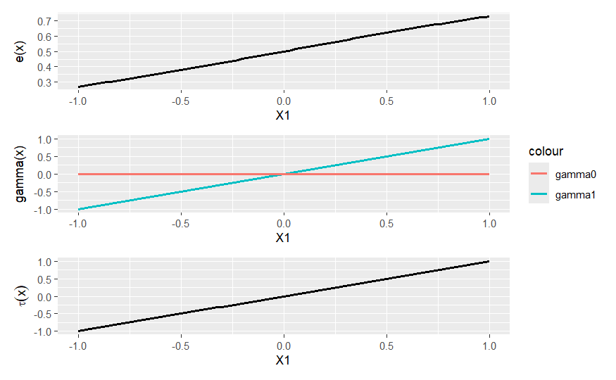

```
# Run the simulation
results = simulation_with_1X(
  alpha0 = alpha0,
  alpha1 = alpha1,
  beta0 = beta0,
  beta1 = beta1,
  beta2 = beta2,
  beta3 = beta3)

# Convert the matrix to a data frame for easier plotting
results_df = as.data.frame(results)

# Melt the data frame to long format for ggplot2
results_long = melt(results_df, id.vars = NULL, variable.name = "Method", value.name = "Value")

# Plot each column as a boxplot
ggplot(results_long, aes(x = Method, y = Value)) +
  geom_boxplot() + geom_hline(yintercept = beta2) +
  theme_minimal() +
  labs(title = "Boxplots of Results by Method", x = "Method", y = "Value")
```

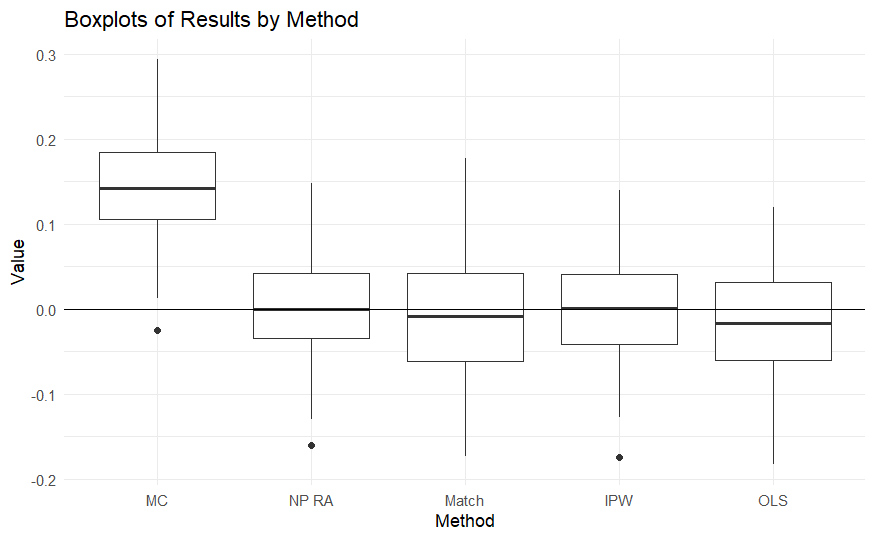

Can you explain the results? Are there any surprises?

- Mean comparison show the expected confounding bias
- Surprisingly OLS is unbiased although it operates under the assumption of homogeneous effects

## Setting with $\alpha_0 = 1$

Repeat the simulation of above but now setting $\alpha_0 = 1$.

How does this change the data generating process?

- It changes the treatment share. Instead of 50:50 split in treated and controls, the majority is now treated because the probability to be treated is shifted upwards for everybody.

```
alpha0 = 1

# Plot the DGP
g1 = data.frame(x = c(-1, 1)) %>% ggplot(aes(x)) + stat_function(fun=e,linewidth=1) + ylab("e(x)") + xlab("X1")
g2 = data.frame(x = c(-1, 1)) %>% ggplot(aes(x)) + stat_function(fun=m1,linewidth=1,aes(colour="gamma1")) +
  stat_function(fun=m0,linewidth=1,aes(colour="gamma0")) + ylab("gamma(x)") + xlab("X1")
g3 = data.frame(x = c(-1, 1)) %>% ggplot(aes(x)) + stat_function(fun=tau,linewidth=1) + ylab(expression(tau(x))) + xlab("X1")
g1 / g2 / g3
```

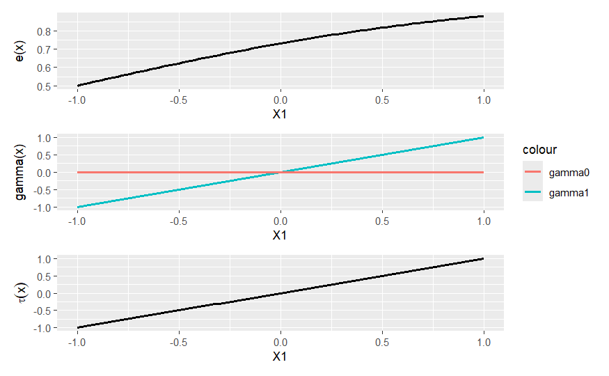

```
# Run the simulation
results = simulation_with_1X(
  alpha0 = alpha0,
  alpha1 = alpha1,
  beta0 = beta0,
  beta1 = beta1,
  beta2 = beta2,
  beta3 = beta3)

# Convert the matrix to a data frame for easier plotting
results_df = as.data.frame(results)

# Melt the data frame to long format for ggplot2
results_long = melt(results_df, id.vars = NULL, variable.name = "Method", value.name = "Value")

# Plot each column as a boxplot
ggplot(results_long, aes(x = Method, y = Value)) +
  geom_boxplot() + geom_hline(yintercept = beta2) +
  theme_minimal() +
  labs(title = "Boxplots of Results by Method", x = "Method", y = "Value")
```

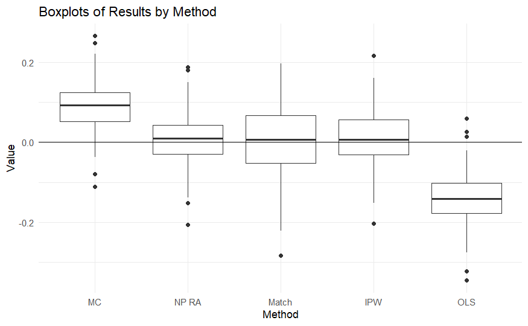

What do you observe?

## Setting with $\alpha_0 = -1$

Repeat the simulation of above but now setting $\alpha_0 = -1$.

How does this change the data generating process?

- It changes the treatment share. Instead of 50:50 split in treated and controls, the majority is now in the control group because the probability to be treated is shifted downwards for everybody.

```
alpha0 = -1

# Plot the DGP
g1 = data.frame(x = c(-1, 1)) %>% ggplot(aes(x)) + stat_function(fun=e,linewidth=1) + ylab("e(x)") + xlab("X1")
g2 = data.frame(x = c(-1, 1)) %>% ggplot(aes(x)) + stat_function(fun=m1,linewidth=1,aes(colour="gamma1")) +
  stat_function(fun=m0,linewidth=1,aes(colour="gamma0")) + ylab("gamma(x)") + xlab("X1")
g3 = data.frame(x = c(-1, 1)) %>% ggplot(aes(x)) + stat_function(fun=tau,linewidth=1) + ylab(expression(tau(x))) + xlab("X1")
g1 / g2 / g3
```

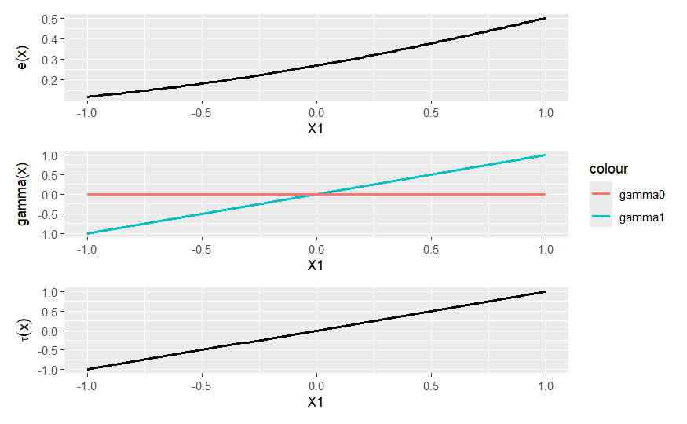

```
# Run the simulation
results = simulation_with_1X(
  alpha0 = alpha0,
  alpha1 = alpha1,
  beta0 = beta0,
  beta1 = beta1,
  beta2 = beta2,
  beta3 = beta3)

# Convert the matrix to a data frame for easier plotting
results_df = as.data.frame(results)

# Melt the data frame to long format for ggplot2
results_long = melt(results_df, id.vars = NULL, variable.name = "Method", value.name = "Value")

# Plot each column as a boxplot
ggplot(results_long, aes(x = Method, y = Value)) +
  geom_boxplot() + geom_hline(yintercept = beta2) +
  theme_minimal() +
  labs(title = "Boxplots of Results by Method", x = "Method", y = "Value")
```

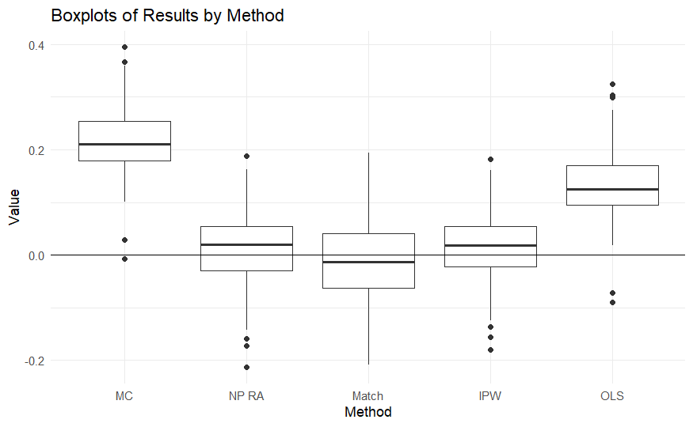

What do you observe?

## Play around with the parameters (optional)

Investigate how the results change for different parameters.